# DSP4SH Phase 2 - SOC Stock and Indicator Analysis

We can plot the SOC stocks by soil and treatment to visually confirm this.

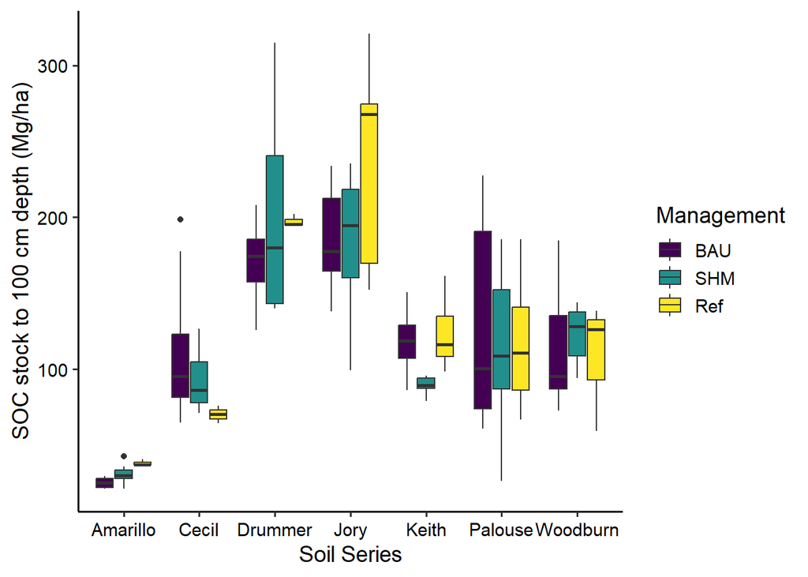

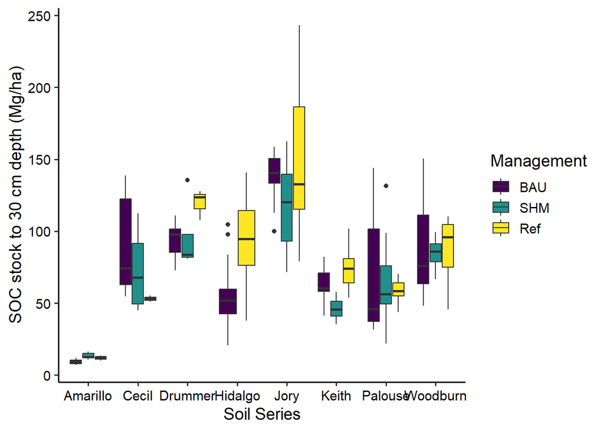

Overall SOC stocks may mask differences between stocks and/or concentrations within depth increments. We can take a look at that with depth plots:

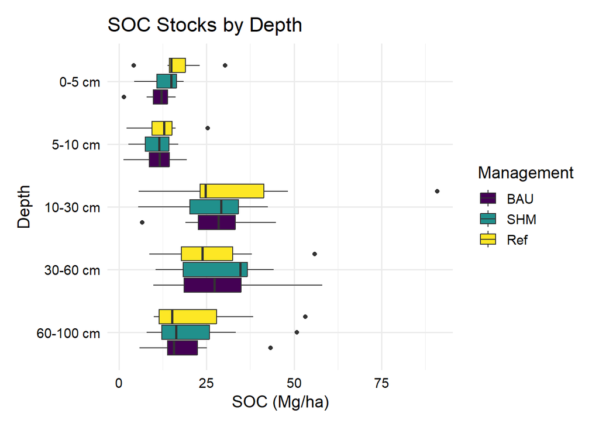

```r
soc_spc <- soc_horizon_filt
depths(soc_spc) <- dsp_pedon_id ~ hrzdep_t + hrzdep_b
hzdesgnname(soc_spc) <- 'hzdesg'
# promote project and label to site-level so they can be used as grouping variables
site(soc_spc) <- ~ project + label + soil

# Calculate depth increments for each soil series in different management conditinos
soc_stock_slab_ref <- aqp::slab(subset(soc_spc, label=="Ref"),
                      fm = soil ~ soc_stock_hrz,
                      slab.structure = c(0,5,10,30,60,100)) %>%
  mutate(label="Ref")

soc_stock_slab_shm <- aqp::slab(subset(soc_spc, label=="SHM"),
                      fm = soil ~ soc_stock_hrz,
                      slab.structure = c(0,5,10,30,60,100)) %>%
  mutate(label="SHM")
soc_stock_slab_bau <- aqp::slab(subset(soc_spc, label=="BAU"),
                      fm = soil ~ soc_stock_hrz,
                      slab.structure = c(0,5,10,30,60,100)) %>%
  mutate(label="BAU")

# Put management conditions together
soc_stock_slab_all <- bind_rows(soc_stock_slab_ref, soc_stock_slab_shm, soc_stock_slab_bau) %>%
  mutate(depth_increment = factor(ifelse(bottom=="5", "0-5 cm",
                                         ifelse(bottom=="10", "5-10 cm",
                                                ifelse(bottom=="30", "10-30 cm",
                                                       ifelse(bottom=="60", "30-60 cm",
                                                       "60-100 cm")))),
                                  levels=c("0-5 cm", "5-10 cm", "10-30 cm", "30-60 cm", "60-100 cm"))) %>%
    mutate(label = factor(label, levels=c("BAU", "SHM", "Ref")))


stock_depth <- ggplot(soc_stock_slab_all, aes(x=depth_increment, y=p.q50, fill=label)) +
  geom_boxplot() +
  coord_flip() +
  scale_x_discrete(limits=rev) +
  scale_fill_viridis(discrete=TRUE, name="Management") +
  labs(title="SOC Stocks by Depth", x="Depth", y="SOC (Mg/ha)") +
  theme_katy_grid()
stock_depth
```

We can also plot SOC concentration by depth - shows that although stocks don’t look that different by horizon, SOC concentration does change in surface horizon.

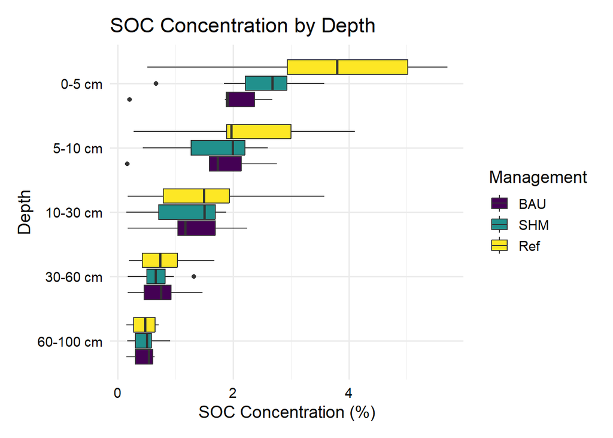

```r
soc_conc_slab_ref <- aqp::slab(subset(soc_spc, label=="Ref"),
                                fm = soil ~ soc_fill,
                                slab.structure = c(0,5,10,30,60,100)) %>%
  mutate(label="Ref")

soc_conc_slab_shm <- aqp::slab(subset(soc_spc, label=="SHM"),
                                fm = soil ~ soc_fill,
                                slab.structure = c(0,5,10,30,60,100)) %>%
  mutate(label="SHM")
soc_conc_slab_bau <- aqp::slab(subset(soc_spc, label=="BAU"),
                                fm = soil ~ soc_fill,
                                slab.structure = c(0,5,10,30,60,100)) %>%
  mutate(label="BAU")

# Put management conditions together
soc_conc_slab_all <- bind_rows(soc_conc_slab_ref, soc_conc_slab_shm, soc_conc_slab_bau) %>%
  mutate(depth_increment = factor(ifelse(bottom=="5", "0-5 cm",
                                         ifelse(bottom=="10", "5-10 cm",
                                                ifelse(bottom=="30", "10-30 cm",
                                                       ifelse(bottom=="60", "30-60 cm",
                                                              "60-100 cm")))),
                                  levels=c("0-5 cm", "5-10 cm", "10-30 cm", "30-60 cm", "60-100 cm"))) %>%
      mutate(label = factor(label, levels=c("BAU", "SHM", "Ref")))


conc_depth <- ggplot(soc_conc_slab_all, aes(x=depth_increment, y=p.q50, fill=label)) +
  geom_boxplot() +
  coord_flip() +
  scale_x_discrete(limits=rev) +
  scale_fill_viridis(discrete=TRUE, name="Management") +
  labs(title="SOC Concentration by Depth", x="Depth", y="SOC Concentration (%)") +
  theme_katy_grid()
conc_depth
```

```r
# Clean data for modeling - want only what's going into the model, and remove any NA values
soc_conc_clean <- soc_horizon_filt %>%
  select(dsp_pedon_id, label, soil, hrzdep_t, hrzdep_b, soc_pct) %>%
  na.omit()

# Random effects: soil, depth
# Fixed effects: label

soc_conc_mixed <- lmer(soc_pct ~ label + (1|soil) + (1|hrzdep_b), data = soc_conc_clean)
summary(soc_conc_mixed)
```

```
## Linear mixed model fit by REML ['lmerMod']
## Formula: soc_pct ~ label + (1 | soil) + (1 | hrzdep_b)
##    Data: soc_conc_clean
##
## REML criterion at convergence: 2045.6
##
## Scaled residuals:
##     Min      1Q  Median      3Q     Max
## -2.5812 -0.5832 -0.0952  0.3818  9.7119
##
## Random effects:
##  Groups   Name        Variance Std.Dev.
##  hrzdep_b (Intercept) 0.1780   0.4219
##  soil     (Intercept) 0.4173   0.6460
##  Residual             0.3803   0.6167
## Number of obs: 1013, groups:  hrzdep_b, 89; soil, 7
##
## Fixed effects:
##             Estimate Std. Error t value
## (Intercept)  0.85961    0.25205   3.410
## labelSHM     0.04895    0.04727   1.036
## labelRef     0.45258    0.05455   8.296
##
## Correlation of Fixed Effects:
##          (Intr) lblSHM
## labelSHM -0.090
## labelRef -0.076  0.411
```

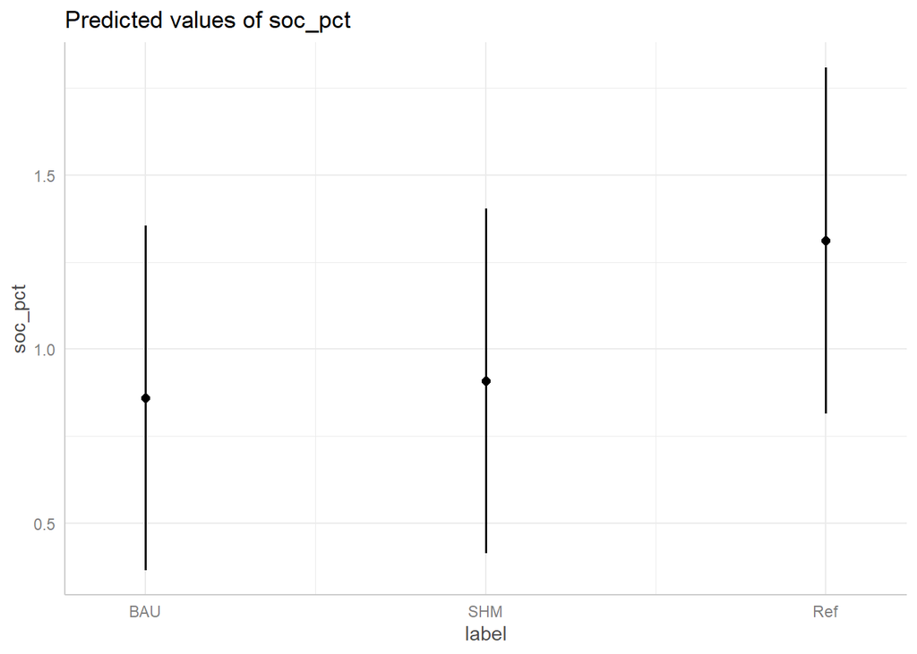

```r
# Plot predictions of SOC concentration for each treatment
pred_soc_conc <- ggpredict(soc_conc_mixed, terms = c("label"))
plot(pred_soc_conc)
```

```r
# Compare full and reduced models, use likelihood ratio test
soc_conc_mixed_full <- lmer(soc_pct ~ label + (1|soil) + (1|hrzdep_b), data = soc_conc_clean, REML = FALSE)
soc_conc_mixed_reduced <- lmer(soc_pct ~ (1|soil) + (1|hrzdep_b), data = soc_conc_clean, REML = FALSE)
anova(soc_conc_mixed_full, soc_conc_mixed_reduced, text="Chisq")
```

```
## Data: soc_conc_clean
## Models:
## soc_conc_mixed_reduced: soc_pct ~ (1 | soil) + (1 | hrzdep_b)
## soc_conc_mixed_full: soc_pct ~ label + (1 | soil) + (1 | hrzdep_b)
##                        npar    AIC    BIC  logLik deviance  Chisq Df Pr(>Chisq)
## soc_conc_mixed_reduced    4 2116.9 2136.6 -1054.4   2108.9
## soc_conc_mixed_full       6 2048.2 2077.7 -1018.1   2036.2 72.696  2  < 2.2e-16
##
## soc_conc_mixed_reduced
## soc_conc_mixed_full    ***
## ---
## Signif. codes:  0 '***' 0.001 '**' 0.01 '*' 0.05 '.' 0.1 ' ' 1
```

```r
# Tukey post-hoc
soc_conc_mixed_tukey <- glht(soc_conc_mixed, linfct = mcp(label = 'Tukey'))
summary(soc_conc_mixed_tukey)
```

```
##
##   Simultaneous Tests for General Linear Hypotheses
##
## Multiple Comparisons of Means: Tukey Contrasts
##
##
## Fit: lmer(formula = soc_pct ~ label + (1 | soil) + (1 | hrzdep_b),
##     data = soc_conc_clean)
##
## Linear Hypotheses:
##                Estimate Std. Error z value Pr(>|z|)
## SHM - BAU == 0  0.04895    0.04727   1.036    0.553
## Ref - BAU == 0  0.45258    0.05455   8.296   <1e-04 ***
## Ref - SHM == 0  0.40363    0.05561   7.259   <1e-04 ***
## ---
## Signif. codes:  0 '***' 0.001 '**' 0.01 '*' 0.05 '.' 0.1 ' ' 1
## (Adjusted p values reported -- single-step method)
```

Results of mixed model: depth and soil both explain a large chunk of variability. Reference appears significant after accounting for variability of soil type and depth. The full model with label as a fixed effect is significantly different from a reduced model with soil and horizon depth as random effects (no fixed effects). Tukey post-hoc shows that Ref is significantly different from both SHM and BAU. SHM and BAU are not significantly different from each other.

We can also run a similar model for SOC stocks.

```r
# Calculate stocks normalized to horizon thickness so each horizon can be comparable - there are different horizon depths in different pits/pedons which may mess up results. This is really capturing soc % x bulk density.

# Clean data for modeling - want only what's going into the model, and remove any NA values
soc_stock_clean <- soc_horizon_filt %>%
  select(dsp_pedon_id, label, soil, hrzdep_t, hrzdep_b, soc_stock_hrz, hrzdepth) %>%
  na.omit() %>%
  mutate(depth_stock = soc_stock_hrz/hrzdepth) # calculate horizon thickness-normalized SOC stocks

# Random effects: soil, pedon
# Fixed effects: label, depth
soc_stock_mixed <- lmer(depth_stock ~ label + (1|soil)  + (1|hrzdep_b), data = soc_stock_clean)
summary(soc_stock_mixed)
```

```
## Linear mixed model fit by REML ['lmerMod']
## Formula: depth_stock ~ label + (1 | soil) + (1 | hrzdep_b)
##    Data: soc_stock_clean
##
## REML criterion at convergence: 2324.4
##
## Scaled residuals:
##     Min      1Q  Median      3Q     Max
## -2.6269 -0.6452 -0.1053  0.4281  5.6624
##
## Random effects:
##  Groups   Name        Variance Std.Dev.
##  hrzdep_b (Intercept) 0.2376   0.4874
##  soil     (Intercept) 0.5827   0.7634
##  Residual             0.4995   0.7067
## Number of obs: 1014, groups:  hrzdep_b, 89; soil, 7
##
## Fixed effects:
##             Estimate Std. Error t value
## (Intercept)  1.30244    0.29739   4.380
## labelSHM     0.02531    0.05417   0.467
## labelRef     0.23205    0.06238   3.720
##
## Correlation of Fixed Effects:
##          (Intr) lblSHM
## labelSHM -0.087
## labelRef -0.074  0.411
```

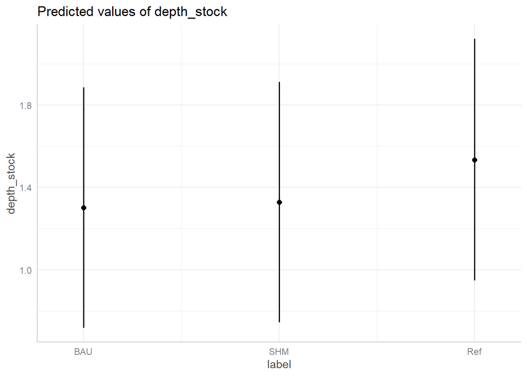

```r
# Plot predictions of thickness-normalized SOC stocks with treatment
pred_soc_stock <- ggpredict(soc_stock_mixed, terms = c("label"))
plot(pred_soc_stock)
```

```r
# Compare full and reduced models, use likelihood ratio test
soc_stock_mixed_full <- lmer(depth_stock ~ label + (1|soil) + (1|hrzdep_b), data = soc_stock_clean, REML = FALSE)
soc_stock_mixed_reduced <- lmer(depth_stock ~ (1|soil) + (1|hrzdep_b), data = soc_stock_clean, REML = FALSE)
anova(soc_stock_mixed_full, soc_stock_mixed_reduced, text="Chisq")
```

```
## Data: soc_stock_clean
## Models:
## soc_stock_mixed_reduced: depth_stock ~ (1 | soil) + (1 | hrzdep_b)
## soc_stock_mixed_full: depth_stock ~ label + (1 | soil) + (1 | hrzdep_b)
##                         npar    AIC    BIC  logLik deviance  Chisq Df
## soc_stock_mixed_reduced    4 2338.9 2358.6 -1165.5   2330.9
## soc_stock_mixed_full       6 2327.8 2357.4 -1157.9   2315.8 15.097  2
##                         Pr(>Chisq)
## soc_stock_mixed_reduced
## soc_stock_mixed_full     0.0005268 ***
## ---
## Signif. codes:  0 '***' 0.001 '**' 0.01 '*' 0.05 '.' 0.1 ' ' 1
```

```r
# Tukey post-hoc
soc_stock_mixed_tukey <- glht(soc_stock_mixed, linfct = mcp(label = 'Tukey'))
summary(soc_stock_mixed_tukey)
```

```
##
##   Simultaneous Tests for General Linear Hypotheses
##
## Multiple Comparisons of Means: Tukey Contrasts
##
##
## Fit: lmer(formula = depth_stock ~ label + (1 | soil) + (1 | hrzdep_b),
##     data = soc_stock_clean)
##
## Linear Hypotheses:
##                Estimate Std. Error z value Pr(>|z|)
## SHM - BAU == 0  0.02531    0.05417   0.467  0.88621
## Ref - BAU == 0  0.23205    0.06238   3.720  < 0.001 ***
## Ref - SHM == 0  0.20674    0.06363   3.249  0.00323 **
## ---
## Signif. codes:  0 '***' 0.001 '**' 0.01 '*' 0.05 '.' 0.1 ' ' 1
## (Adjusted p values reported -- single-step method)
```

Results of mixed model: depth and soil both explain a large chunk of variability. Reference appears significant after accounting for variability of soil type and depth. The full model with label as a fixed effect is significantly different from a reduced model with soil and horizon depth as random effects (no fixed effects). Tukey post-hoc shows that Ref is significantly different from both SHM and BAU. SHM and BAU are not significantly different from each other.

It’s interesting that SOC concentration is so much more sensitive to management in the surface horizon than SOC stocks. That suggests that bulk density is probably also sensitive to management and may be moderating the effect of SOC concentration on overall stocks. Test this by plotting and with a mixed linear model:

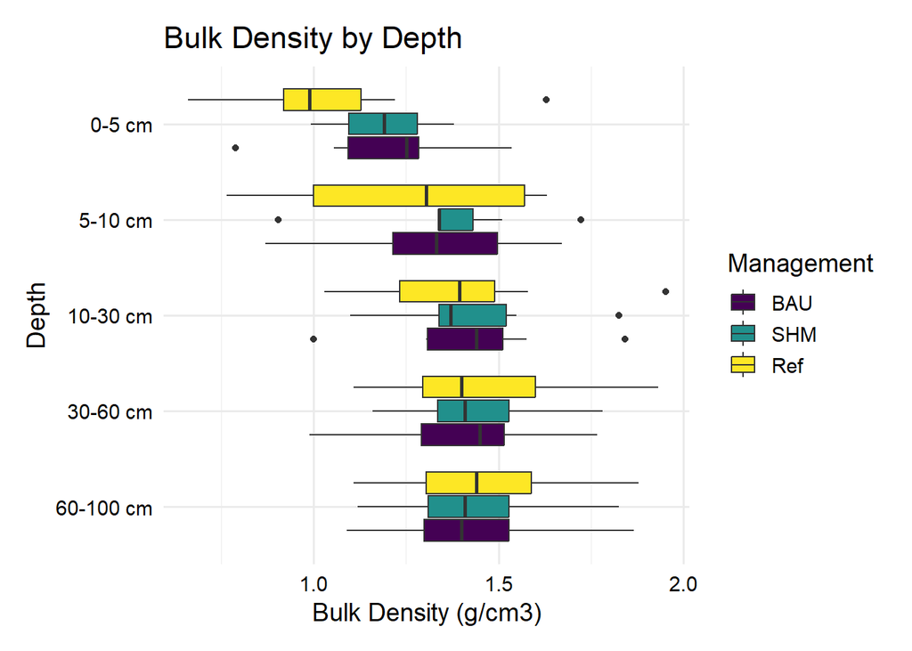

```r
# Calculate depth increments for each soil series in different management conditinos
bd_slab_ref <- aqp::slab(subset(soc_spc, label=="Ref"),
                         fm = soil ~ bd_fill,
                         slab.structure = c(0,5,10,30,60,100)) %>%
  mutate(label="Ref")

bd_slab_shm <- aqp::slab(subset(soc_spc, label=="SHM"),
                         fm = soil ~ bd_fill,
                         slab.structure = c(0,5,10,30,60,100)) %>%
  mutate(label="SHM")
bd_slab_bau <- aqp::slab(subset(soc_spc, label=="BAU"),
                         fm = soil ~ bd_fill,
                         slab.structure = c(0,5,10,30,60,100)) %>%
  mutate(label="BAU")

# Put management conditions together
bd_slab_all <- bind_rows(bd_slab_ref, bd_slab_shm, bd_slab_bau) %>%
  mutate(depth_increment = factor(ifelse(bottom=="5", "0-5 cm",
                                         ifelse(bottom=="10", "5-10 cm",
                                                ifelse(bottom=="30", "10-30 cm",
                                                       ifelse(bottom=="60", "30-60 cm",
                                                              "60-100 cm")))),
                                  levels=c("0-5 cm", "5-10 cm", "10-30 cm", "30-60 cm", "60-100 cm"))) %>%
  mutate(label = factor(label, levels=c("BAU", "SHM", "Ref")))

# Plot bulk density with depth
bd_depth <- ggplot(bd_slab_all, aes(x=depth_increment, y=p.q50, fill=label)) +
  geom_boxplot() +
  coord_flip() +
  scale_x_discrete(limits=rev) +
  scale_fill_viridis(discrete=TRUE, name="Management") +
  labs(title="Bulk Density by Depth", x="Depth", y="Bulk Density (g/cm3)") +
  theme_katy_grid()
bd_depth
```

```r
# Mixed model for bulk density response to soil, depth, and management
bd_clean <- soc_horizon_filt %>%
  select(dsp_pedon_id, label, soil, hrzdep_t, hrzdep_b, bd_fill) %>%
  na.omit()

# Random effects: soil
# Fixed effects: label, depth

bd_mixed <- lmer(bd_fill ~ label + (1|soil) + (1|hrzdep_b), data = bd_clean)
summary(bd_mixed)
```

```
## Linear mixed model fit by REML ['lmerMod']
## Formula: bd_fill ~ label + (1 | soil) + (1 | hrzdep_b)
##    Data: bd_clean
##
## REML criterion at convergence: -564.4
##
## Scaled residuals:
##     Min      1Q  Median      3Q     Max
## -6.6842 -0.4819  0.0322  0.4792  4.0395
##
## Random effects:
##  Groups   Name        Variance Std.Dev.
##  hrzdep_b (Intercept) 0.003778 0.06146
##  soil     (Intercept) 0.047756 0.21853
##  Residual             0.030381 0.17430
## Number of obs: 1014, groups:  hrzdep_b, 89; soil, 7
##
## Fixed effects:
##              Estimate Std. Error t value
## (Intercept)  1.431241   0.083623  17.115
## labelSHM    -0.004044   0.013139  -0.308
## labelRef    -0.063633   0.015046  -4.229
##
## Correlation of Fixed Effects:
##          (Intr) lblSHM
## labelSHM -0.075
## labelRef -0.064  0.413
```

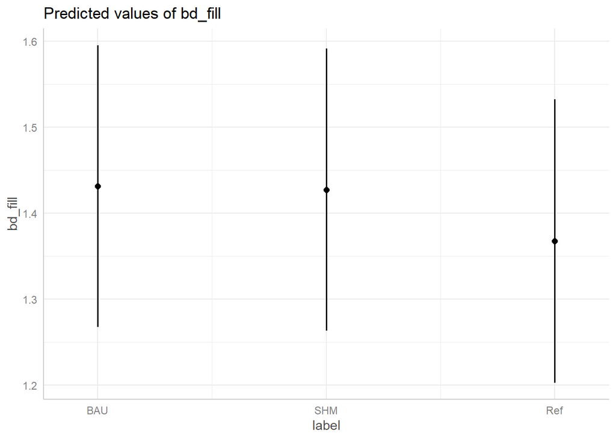

```r
# Results of mixing model: Soil explains the most of the random effects variability, Ref appears significant as a fixed effect

# Plot predictions of SOC concentration for each treatment
pred_bd <- ggpredict(bd_mixed, terms = c("label"))
plot(pred_bd)
```

```r
# Test by comparing full and reduced models, use likelihood ratio test
bd_mixed_full <- lmer(bd_fill ~ label + (1|soil) + (1|hrzdep_b), data = bd_clean, REML = FALSE)
bd_mixed_reduced <- lmer(bd_fill ~ (1|soil) + (1|hrzdep_b), data = bd_clean, REML = FALSE)
anova(bd_mixed_full, bd_mixed_reduced, text="Chisq")
```

```
## Data: bd_clean
## Models:
## bd_mixed_reduced: bd_fill ~ (1 | soil) + (1 | hrzdep_b)
## bd_mixed_full: bd_fill ~ label + (1 | soil) + (1 | hrzdep_b)
##                  npar     AIC     BIC logLik deviance  Chisq Df Pr(>Chisq)
## bd_mixed_reduced    4 -552.98 -533.29 280.49  -560.98
## bd_mixed_full       6 -569.21 -539.68 290.60  -581.21 20.224  2  4.058e-05 ***
## ---
## Signif. codes:  0 '***' 0.001 '**' 0.01 '*' 0.05 '.' 0.1 ' ' 1
```

```r
# Models are significantly different

# Are there significantly different groups?
bd_mixed_tukey <- glht(bd_mixed, linfct = mcp(label = 'Tukey'))
summary(bd_mixed_tukey)
```

```
##
##   Simultaneous Tests for General Linear Hypotheses
##
## Multiple Comparisons of Means: Tukey Contrasts
##
##
## Fit: lmer(formula = bd_fill ~ label + (1 | soil) + (1 | hrzdep_b),
##     data = bd_clean)
##
## Linear Hypotheses:
##                 Estimate Std. Error z value Pr(>|z|)
## SHM - BAU == 0 -0.004044   0.013139  -0.308    0.949
## Ref - BAU == 0 -0.063633   0.015046  -4.229   <0.001 ***
## Ref - SHM == 0 -0.059589   0.015347  -3.883   <0.001 ***
## ---
## Signif. codes:  0 '***' 0.001 '**' 0.01 '*' 0.05 '.' 0.1 ' ' 1
## (Adjusted p values reported -- single-step method)
```

```r
# Ref is significantly different from both SHM and BAU. SHM and BAU are not significantly different from each other.
```

Results of mixed linear model: bulk density is indeed sensitive to management. It is significantly lower in the Ref management group vs the SHM and BAU groups, especially in the surface (0-5cm) horizon.

Put these depth plots together into one gridded plot:

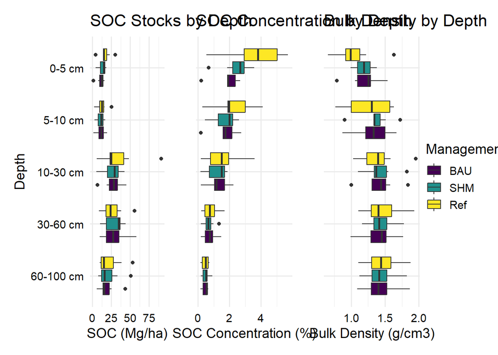

```r
stock_depth2 <- stock_depth + theme(legend.position="none")
conc_depth2 <- conc_depth + theme(legend.position="none", axis.title.y=element_blank(), axis.text.y=element_blank()) #remove y axis from conc plot so axes can be shared
bd_depth2 <- bd_depth + theme(legend.position="none", axis.title.y=element_blank(), axis.text.y=element_blank())
depth_plot_legend <- get_legend(stock_depth)

depth_plot_grid <- plot_grid(stock_depth2, conc_depth2, bd_depth2, depth_plot_legend, labels="",
                             rel_widths=c(1.4,1,1, .5), nrow=1)
depth_plot_grid
```

## Analyses of just the surface horizons - since these appear most sensitive to management

It might be useful to also separate out the 0-5 and 5-10cm depth classes since these were the only ones that are consistent across all the experiments (and surface horizons appear significantly more sensitive to management)

```r
# Subset just 0-5 cm horizon
soc_stock_clean_5 <- soc_stock_clean %>%
  filter(hrzdep_b == 5)

soc_stock5_mixed <- lmer(soc_stock_hrz ~ label + (1|soil), data = soc_stock_clean_5)
summary(soc_stock5_mixed)
```

```
## Linear mixed model fit by REML ['lmerMod']
## Formula: soc_stock_hrz ~ label + (1 | soil)
##    Data: soc_stock_clean_5
##
## REML criterion at convergence: 1031.8
##
## Scaled residuals:
##     Min      1Q  Median      3Q     Max
## -2.2082 -0.5695 -0.0839  0.4370  3.5092
##
## Random effects:
##  Groups   Name        Variance Std.Dev.
##  soil     (Intercept) 24.76    4.976
##  Residual             20.19    4.494
## Number of obs: 174, groups:  soil, 7
##
## Fixed effects:
##             Estimate Std. Error t value
## (Intercept)  11.2533     1.9608   5.739
## labelSHM      2.3578     0.7993   2.950
## labelRef      4.6803     0.9156   5.112
##
## Correlation of Fixed Effects:
##          (Intr) lblSHM
## labelSHM -0.199
## labelRef -0.173  0.425
```

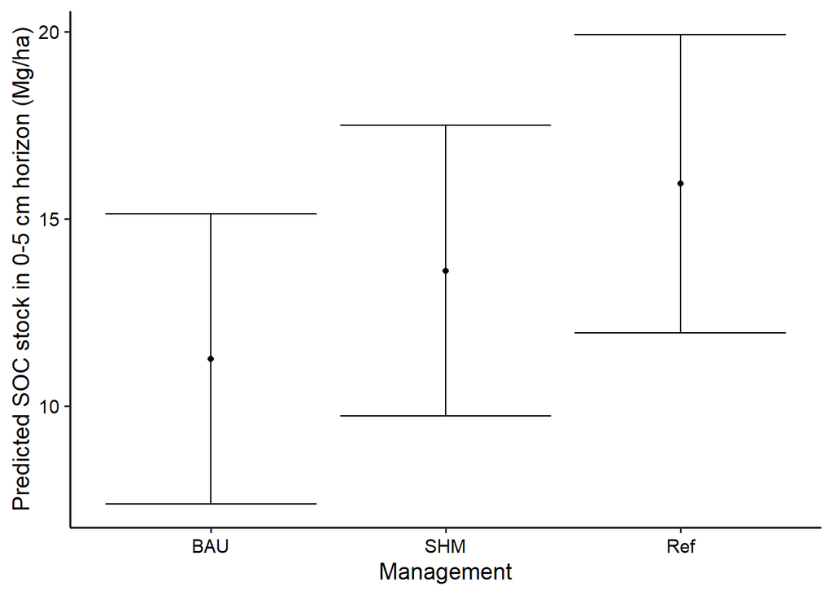

```r
# Plot predictions
pred_soc_stock5 <- ggpredict(soc_stock5_mixed, terms = c("label"))
ggplot(pred_soc_stock5, aes(x=x, y=predicted)) +
  geom_point() +
  geom_errorbar(aes(x=x, ymin=conf.low, ymax=conf.high)) +
  labs(x="Management", y="Predicted SOC stock in 0-5 cm horizon (Mg/ha)") +
  theme_katy()
```

```r
# Test significance of reduced model
soc_stock5_mixed_full <- lmer(soc_stock_hrz ~ label + (1|soil), data = soc_stock_clean_5, REML = FALSE)
soc_stock5_mixed_reduced <- lmer(soc_stock_hrz ~ (1|soil), data = soc_stock_clean_5, REML = FALSE)
anova(soc_stock5_mixed_full, soc_stock5_mixed_reduced, text="Chisq")
```

```
## Data: soc_stock_clean_5
## Models:
## soc_stock5_mixed_reduced: soc_stock_hrz ~ (1 | soil)
## soc_stock5_mixed_full: soc_stock_hrz ~ label + (1 | soil)
##                          npar    AIC    BIC  logLik deviance  Chisq Df
## soc_stock5_mixed_reduced    3 1068.8 1078.3 -531.42   1062.8
## soc_stock5_mixed_full       5 1047.7 1063.5 -518.84   1037.7 25.149  2
##                          Pr(>Chisq)
## soc_stock5_mixed_reduced
## soc_stock5_mixed_full     3.458e-06 ***
## ---
## Signif. codes:  0 '***' 0.001 '**' 0.01 '*' 0.05 '.' 0.1 ' ' 1
```

```r
# Two models are significantly different

# test for significantly different groups
soc_stock5_mixed_tukey <- glht(soc_stock5_mixed, linfct = mcp(label = 'Tukey'))
summary(soc_stock5_mixed_tukey)
```

```
##
##   Simultaneous Tests for General Linear Hypotheses
##
## Multiple Comparisons of Means: Tukey Contrasts
##
##
## Fit: lmer(formula = soc_stock_hrz ~ label + (1 | soil), data = soc_stock_clean_5)
##
## Linear Hypotheses:
##                Estimate Std. Error z value Pr(>|z|)
## SHM - BAU == 0   2.3578     0.7993   2.950  0.00905 **
## Ref - BAU == 0   4.6803     0.9156   5.112  < 0.001 ***
## Ref - SHM == 0   2.3225     0.9251   2.511  0.03188 *
## ---
## Signif. codes:  0 '***' 0.001 '**' 0.01 '*' 0.05 '.' 0.1 ' ' 1
## (Adjusted p values reported -- single-step method)
```

```r
# All groups are significantly different!!
```

Results of mixed model: soil explains a lot of the variance. The full model with label as a fixed effect and soil as a random effect is significantly different from the reduced model with just soil as a random effect. Tukey post-hoc test shows that all treatment groups are significantly different from each other. This is the first analysis where SHM has been significantly different from BAU.

Repeat with the 5-10cm depth:

```r
soc_stock_clean_10 <- soc_stock_clean %>%
  filter(hrzdep_b == 10)

soc_stock10_mixed <- lmer(soc_stock_hrz ~ label + (1|soil), data = soc_stock_clean_10)
summary(soc_stock10_mixed)
```

```
## Linear mixed model fit by REML ['lmerMod']
## Formula: soc_stock_hrz ~ label + (1 | soil)
##    Data: soc_stock_clean_10
##
## REML criterion at convergence: 925.3
##
## Scaled residuals:
##     Min      1Q  Median      3Q     Max
## -2.6791 -0.6070 -0.0770  0.5151  4.5875
##
## Random effects:
##  Groups   Name        Variance Std.Dev.
##  soil     (Intercept) 32.21    5.676
##  Residual             10.49    3.240
## Number of obs: 174, groups:  soil, 7
##
## Fixed effects:
##             Estimate Std. Error t value
## (Intercept)  11.6865     2.1821   5.356
## labelSHM     -0.1754     0.5765  -0.304
## labelRef      0.9942     0.6604   1.505
##
## Correlation of Fixed Effects:
##          (Intr) lblSHM
## labelSHM -0.129
## labelRef -0.112  0.424
```

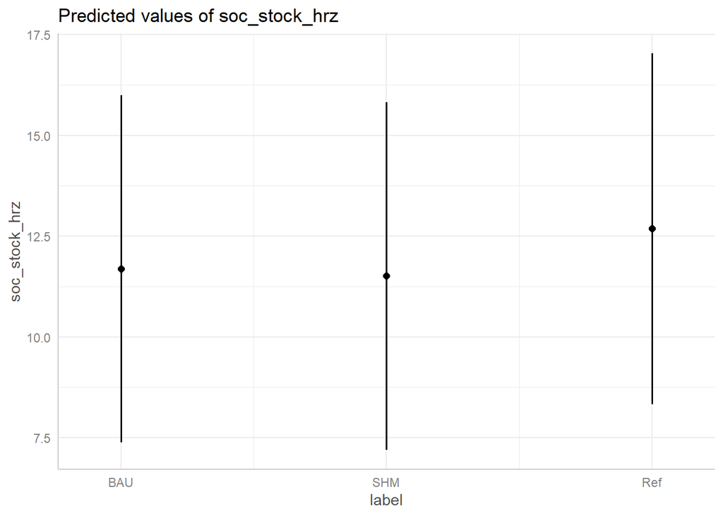

```r
# Plot predictions
pred_soc_stock10 <- ggpredict(soc_stock10_mixed, terms = c("label"))
plot(pred_soc_stock10)
```

```r
# Test significance of reduced model
soc_stock10_mixed_full <- lmer(soc_stock_hrz ~ label + (1|soil), data = soc_stock_clean_10, REML = FALSE)
soc_stock10_mixed_reduced <- lmer(soc_stock_hrz ~ (1|soil), data = soc_stock_clean_10, REML = FALSE)
anova(soc_stock10_mixed_full, soc_stock10_mixed_reduced, text="Chisq")
```

```
## Data: soc_stock_clean_10
## Models:
## soc_stock10_mixed_reduced: soc_stock_hrz ~ (1 | soil)
## soc_stock10_mixed_full: soc_stock_hrz ~ label + (1 | soil)
##                           npar    AIC    BIC  logLik deviance  Chisq Df
## soc_stock10_mixed_reduced    3 939.47 948.95 -466.74   933.47
## soc_stock10_mixed_full       5 940.10 955.89 -465.05   930.10 3.3755  2
##                           Pr(>Chisq)
## soc_stock10_mixed_reduced
## soc_stock10_mixed_full        0.1849
```

```r
soc_stock10_mixed_tukey <- glht(soc_stock10_mixed, linfct = mcp(label = 'Tukey'))
summary(soc_stock10_mixed_tukey)
```

```
##
##   Simultaneous Tests for General Linear Hypotheses
##
## Multiple Comparisons of Means: Tukey Contrasts
##
##
## Fit: lmer(formula = soc_stock_hrz ~ label + (1 | soil), data = soc_stock_clean_10)
##
## Linear Hypotheses:
##                Estimate Std. Error z value Pr(>|z|)
## SHM - BAU == 0  -0.1754     0.5765  -0.304    0.950
## Ref - BAU == 0   0.9942     0.6604   1.505    0.287
## Ref - SHM == 0   1.1697     0.6674   1.753    0.185
## (Adjusted p values reported -- single-step method)
```

# What do other soil health indicators tell us ?

## Principal Components Analysis of indicator data

There are a lot of missing values in the indicator data because not every metric was measured by every cooperator. PCA doesn’t handle missing values, so I used the missMDA package to impute missing data. The package imputes missing values so that the imputed values have no weight on the results (i.e. just allows the analysis to be completed).

```r
# Make df of only numeric indicator values
indicators_only <- soc_horizon_filt %>%
  select(bulk_density, soc_pct, tn_pct:yoder_agg_stab_mwd, p_h:ace, clay_pct_field)

nb2 <- estim_ncpPCA(indicators_only,method.cv = "Kfold", verbose = FALSE) # estimate the number of components from incomplete data
nb2$ncp
```

```
## [1] 1
```

```r
res.comp2 <- imputePCA(indicators_only, ncp = nb2$ncp)
imp_ind <- res.comp2$completeObs
imp_pca2 <- prcomp(imp_ind, scale.=TRUE)
summary(imp_pca2)
```

```
## Importance of components:
##                           PC1    PC2    PC3     PC4     PC5     PC6     PC7
## Standard deviation     2.4707 1.3656 1.2911 1.04834 0.99702 0.86427 0.79518
## Proportion of Variance 0.3815 0.1166 0.1042 0.06869 0.06213 0.04669 0.03952
## Cumulative Proportion  0.3815 0.4981 0.6023 0.67096 0.73309 0.77977 0.81929
##                            PC8     PC9    PC10    PC11    PC12    PC13    PC14
## Standard deviation     0.74930 0.68625 0.64273 0.58737 0.55673 0.54472 0.50426
## Proportion of Variance 0.03509 0.02943 0.02582 0.02156 0.01937 0.01854 0.01589
## Cumulative Proportion  0.85438 0.88381 0.90963 0.93120 0.95057 0.96911 0.98500
##                           PC15    PC16
## Standard deviation     0.43871 0.21789
## Proportion of Variance 0.01203 0.00297
## Cumulative Proportion  0.99703 1.00000
```

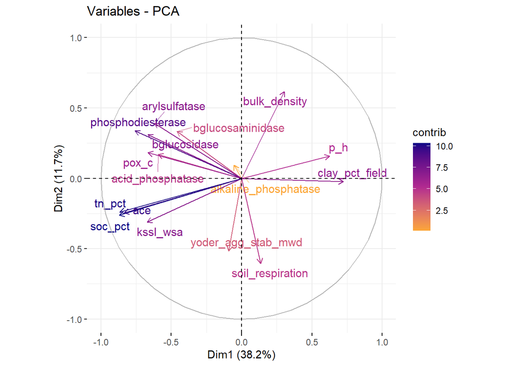

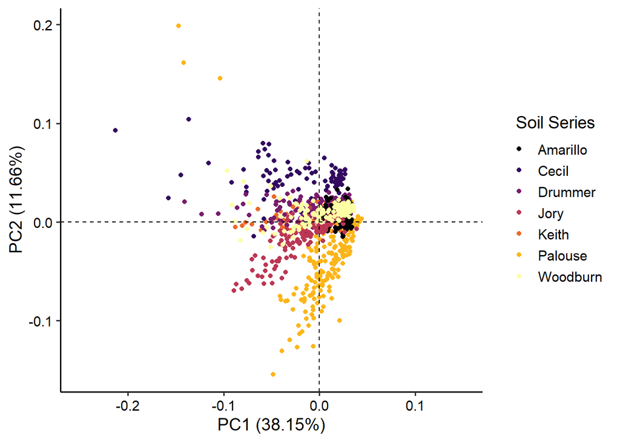

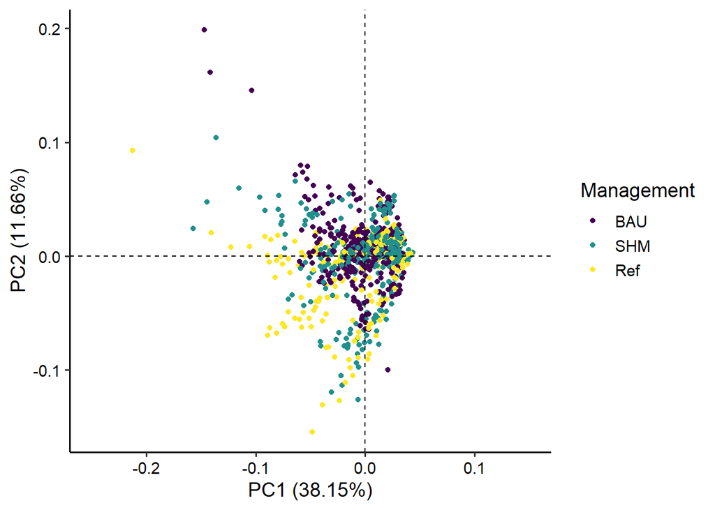

The loadings plot shows that some of the variables that strongly influenced the principal components are bulk density, soil respiration, aggregate MWD, clay, SOC%, phosphodiesterase, and ACE. A few variables grouped together pretty closely: SOC% and ACE stand out as very close, and most of the enzyme activities are bunched pretty closely together which makes sense. It’s really cool to see how closely SOC% and water-stable aggregates are correlated!

I would take this with a grain of salt because there are imputed variables - the loadings plot may be more reflective of which variables had the most real data.

The first PCA score plot (colored by soil series) shows that the data cluster very strongly by soil series. The second PCA score plot (colored by management) shows that the data do not cluster particularly strongly by management. Note - I had tried to show both these things at once by coloring data by soil series and using shape to denote different management, but I personally found it too busy to read on one figure.

This finding is really consistent with what we see by looking at just the SOC data - soils group much more strongly by soil series than by management groupings. This makes a lot of sense, of course. It is exciting to see that SOC% groups pretty closely with many other variables on the loading plot - many of the soil health metrics we’re looking at are likely to reflect something about a soil sample’s carbon content.

## Use a correlation matrix to look at the structure and covariance of the soil health metrics

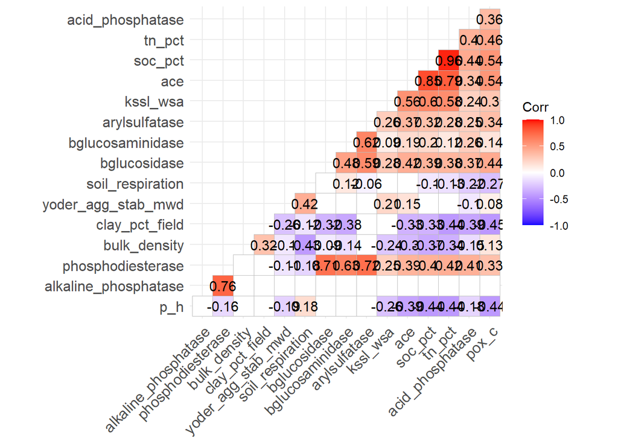

```r
indicators_normalized <- scale(indicators_only)

corr_matrix <- cor(indicators_normalized, use="pairwise.complete.obs")
corr_pmat <- cor_pmat(indicators_normalized)

ggcorrplot(corr_matrix, p.mat=corr_pmat, hc.order=TRUE, type="lower", lab=TRUE, insig="blank")
```

## Mixed linear model of treatment and soil effects on all other assessed soil health indicators

First, make a big mixed linear model for assessing effect of treatment and soil on all assessed soil health indicators (0-5cm values ONLY).

```r
# Filter and pivot data
surf <- soc_horizon_filt %>%
  filter(hrzdep_b == "5")

surf_indicator <- surf %>%
  select(dsp_pedon_id, soil, label, soc_stock_hrz, soc_pct, bulk_density, tn_pct:yoder_agg_stab_mwd, p_h:ace) %>%
  pivot_longer(soc_stock_hrz:ace, names_to="indicator", values_to="value")

# Run full and reduced mixed model for each indicator, ANOVA to compare models, and arrange indicators from lowest to highest P value
lmm_sig <- surf_indicator %>%
  group_by(indicator) %>%
  nest() %>%
  mutate(anova_obj = map(data, ~{
    lmer_full <- lmer(value ~ label + (1|soil), data = ., REML=FALSE)
    lmer_reduced <- lmer(value ~ (1|soil), data = ., REML=FALSE)
    anova(lmer_full, lmer_reduced, text="Chisq")
    })) %>%
  mutate(anova_tidy = map(anova_obj, broom::tidy)) %>%
  ungroup() %>%
  transmute(indicator, anova_tidy) %>%
  unnest(cols = c(anova_tidy)) %>%
  filter(term == "lmer_full") %>%
  filter(p.value < 0.05) %>%
  arrange(p.value) %>%
  select(indicator, deviance:p.value)
```

```
## boundary (singular) fit: see help('isSingular')
## boundary (singular) fit: see help('isSingular')
```

```r
flextable(lmm_sig)
```

| indicator | deviance | statistic | df | p.value |
| --- | --- | --- | --- | --- |
| kssl_wsa | 1,083.66285 | 75.028426 | 2 | 0.00000000000000005102516 |
| soc_pct | 442.44286 | 74.987329 | 2 | 0.00000000000000005208448 |
| ace | 856.09651 | 53.494583 | 2 | 0.00000000000241990798674 |
| tn_pct | -343.15986 | 45.518850 | 2 | 0.00000000013052905847312 |
| pox_c | 2,314.81846 | 33.517160 | 2 | 0.00000005270371985005844 |
| soc_stock_hrz | 1,037.68896 | 25.149529 | 2 | 0.00000345819323877813658 |
| bglucosidase | 2,333.44771 | 13.386454 | 2 | 0.00123927691755864309055 |
| arylsulfatase | 2,146.65866 | 11.559453 | 2 | 0.00308956038490357286566 |
| bulk_density | 1.26708 | 10.768174 | 2 | 0.00458902849645617498531 |
| yoder_agg_stab_mwd | 1,058.14199 | 9.544301 | 2 | 0.00846216396400020776092 |
| acid_phosphatase | 2,049.38745 | 7.538420 | 2 | 0.02307028427022238259436 |
| alkaline_phosphatase | 2,395.04351 | 6.864688 | 2 | 0.03231110717977776769505 |
| bglucosaminidase | 2,100.57793 | 6.224324 | 2 | 0.04450464058197608346878 |

The soil health indicators where treatment has the strongest effect are: water-stable aggregates, SOC%, ACE, total N, POX-C, SOC horizon stock, and b-glucosidase.

We can also split the data up by soil series to look at which indicators are the most sensitive to management within a particular soil series (which also means within a particular project here).

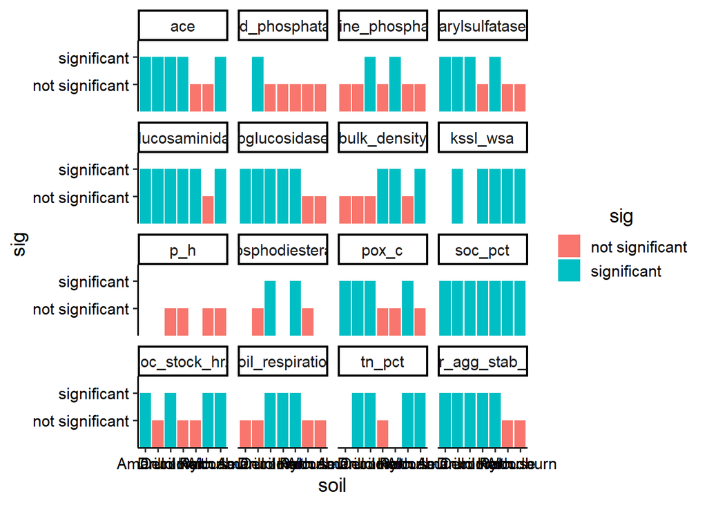

```r
soil_anova <- surf_indicator %>%
  na.omit() %>%
  group_by(soil, indicator) %>%
  nest() %>%
  mutate(anova_obj = map(data, ~anova(aov(value ~ label, data=.x)))) %>%
  mutate(anova_tidy = map(anova_obj, broom::tidy)) %>%
  ungroup() %>%
  transmute(soil, indicator, anova_tidy) %>%
  unnest(cols = c(anova_tidy)) %>%
  filter(term=="label") %>%
  mutate(sig = ifelse(p.value<0.05, "significant", "not significant"))

# Plot which indicators are significantly influenced by management in which soil series
ggplot(soil_anova, aes(x=soil, y=sig, fill=sig)) +
  geom_bar(stat="identity") +
  facet_wrap(vars(indicator)) +
  theme_katy()
```

```r
# Make table of top 3 indicators most significantly influenced by management in each soil series
soil_indicator_top3 <- soil_anova %>%
  group_by(soil) %>%
  arrange(p.value, .by_group=TRUE) %>%
  slice_head(n=3) %>%
  select(soil, indicator, p.value)
flextable(soil_indicator_top3)
```

| soil | indicator | p.value |
| --- | --- | --- |
| Amarillo | pox_c | 0.0000000001622497755 |
| Amarillo | soc_pct | 0.0000000030500059692 |
| Amarillo | soc_stock_hrz | 0.0000000655617852079 |
| Cecil | kssl_wsa | 0.0000000845395228102 |
| Cecil | pox_c | 0.0015998586745482578 |
| Cecil | arylsulfatase | 0.0032702127280376625 |
| Drummer | pox_c | 0.0000000106657545970 |
| Drummer | soc_pct | 0.0000000286712351411 |
| Drummer | ace | 0.0000000287173392147 |
| Jory | bglucosidase | 0.0000000005639981409 |
| Jory | ace | 0.0000001948619434197 |
| Jory | bulk_density | 0.0000011780830694209 |
| Keith | kssl_wsa | 0.0000000000004894134 |
| Keith | bglucosaminidase | 0.0000000000476630032 |
| Keith | bglucosidase | 0.0000000034205093004 |
| Palouse | kssl_wsa | 0.0018518750863233990 |
| Palouse | pox_c | 0.0019308287029129064 |
| Palouse | soc_stock_hrz | 0.0155157225327065013 |
| Woodburn | ace | 0.0000377979419590549 |
| Woodburn | soc_stock_hrz | 0.0000461380738958153 |
| Woodburn | soc_pct | 0.0001476527285953013 |

Heavy hitters: SOC%, water-stable aggregates, POX-C, ACE, and various enzyme activities (most often b-glucosidase)